# Unit testing

04/13/2020

## Unit testing

- If you write the same code repeatedly, you should write a function
  - for coding efficiency
  - for clarity
  - to reduce the introduction of bugs when modifying your code
- If you use the same function in different settings, it may be useful to write a package
- As that package evolves, it is important that your functions not break on your old code

## Unit testing

- The concept: you write a script that automatically evaluates pieces of your code and checks it against expected behavior
- The `testthat` package is a convenient way to do so

## A toy example

```r
find_real_roots <- function(p, q){
  # Find roots of x^2 + px + q = 0
  (-p  + c(-1, 1) * sqrt(p^2 - 4 * q))/2
}


find_real_roots(-5, 1)
```

```
## [1] 0.2087122 4.7912878
```

```r
find_real_roots(2, 1)
```

```
## [1] -1 -1
```

```r
find_real_roots(0, 1)
```

```
## [1] NaN NaN
```

```r
find_real_roots(0, NA)
```

```
## [1] NA NA
```

```r
find_real_roots("A", "B")
```

```
## Error in -p: invalid argument to unary operator
```

```r
find_real_roots(1:4, 0)
```

```
## [1] -1  0 -3  0
```

## Improving the function

```r
find_real_roots <- function(p, q){
  # Find roots of x^2 + px + q = 0
  if
    (!(class(p) %in% c("numeric", "integer")) |
    !(class(q) %in% c("numeric", "integer"))
  ) stop("Input must be two numbers")
  if (length(p) != 1 | length(q) != 1) stop ("p and q must each have length 1")
  (-p  + c(-1, 1) * sqrt(p^2 - 4 * q))/2
}

find_real_roots("A", "B")
```

```
## Error in find_real_roots("A", "B"): Input must be two numbers
```

```r
find_real_roots(1:4, 0)
```

```
## Error in find_real_roots(1:4, 0): p and q must each have length 1
```

## Back to unit testing

- Might want to test that
  - arguments that are not numbers lead to errors
  - if both arguments aren’t of length 1 then there is an error
  - if an argument is NA, then the result is c(NA, NA)
  - the result is a numeric vector of length 2
  - maybe confirm a few values

## Using the `testthat` package

- You write a series of expectations, as below:

```r
library(testthat)
test_that("find_real_roots returns a numeric vector of length 2", {
  expect_is(find_real_roots(5, 2), "numeric")
  expect_length(find_real_roots(5, 2), 2)
})

test_that("find_real_roots gives errors for non-numbers or vectors", {
   expect_error(find_real_roots("A", "B"), "Input must be two numbers")
   expect_error(find_real_roots(1:4, 0), "p and q must each have length 1")

})


test_that("find_real_roots gives correct values for some examples", {
  expect_equal(find_real_roots(2, 1), c(-1, -1))
  expect_equal(find_real_roots(0, -1), c(-1, 1))
  expect_equal(find_real_roots(5, 2), c(-4.5615528, -0.4384472))
})
```

If there is no problem then each test will return nothing. If there is a problem you’ll get something like this

```r
expect_equal(find_real_roots(2, 1), c(-1, 5))
```

```
## Error: find_real_roots(2, 1) not equal to c(-1, 5).
## 1/2 mismatches
## [2] -1 - 5 == -6
```

or

```r
test_that("intentional failure", {
  expect_equal(find_real_roots(2, 1), c(-1, 5))
})
```

```
## Error: Test failed: 'intentional failure'
## * find_real_roots(2, 1) not equal to c(-1, 5).
## 1/2 mismatches
## [2] -1 - 5 == -6
```

Typically you would put all of these in a file, say `test_find_real_roots.R`.

The **very first** line of the file has to be

```r
context("Some explanatory string")
```

where “Some explanatory string” is a description of what you are testing, like “String processing”.

With the file created, you can run all of the tests with

```r
test_file("test_find_real_roots.R")
```

```
## ✔ | OK F W S | Context
##
⠏ |  0       | Unit Test Examples
⠋ |  1       | Unit Test Examples
⠙ |  2       | Unit Test Examples
⠹ |  3       | Unit Test Examples
⠸ |  4       | Unit Test Examples
⠼ |  5       | Unit Test Examples
⠴ |  6       | Unit Test Examples
⠦ |  7       | Unit Test Examples
⠧ |  7 1     | Unit Test Examples
✖ |  7 1     | Unit Test Examples
## ────────────────────────────────────────────────────
## test_find_real_roots.R:23: failure: intentional error
## find_real_roots(2, 1) not equal to c(-1, 5).
## 1/2 mismatches
## [2] -1 - 5 == -6
## ────────────────────────────────────────────────────
##
## ══ Results ═════════════════════════════════════════
## OK:       7
## Failed:   1
## Warnings: 0
## Skipped:  0
```

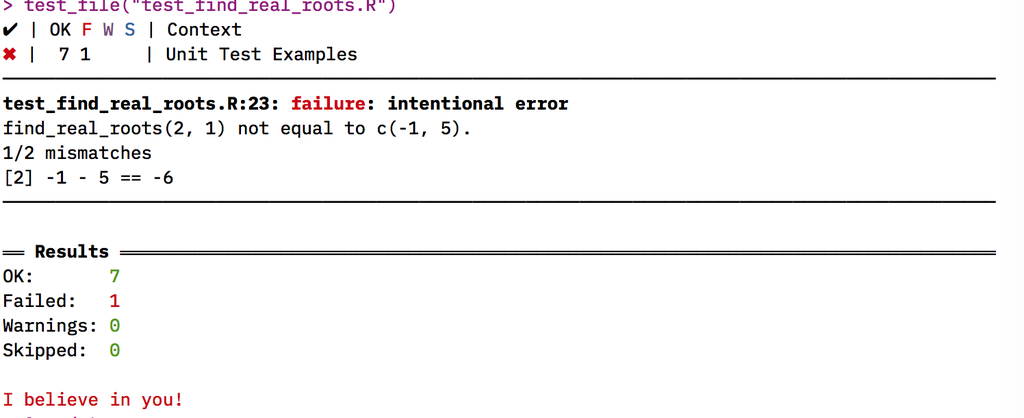

test_file output

To add this approach to a package,

- Type `devtools::use_testthat()` to add a `tests` directory to your package
- Create a test file as above:
  - in goes in the `tests/testthat/` directory
  - its name must start with `test`
- Use `devtools::test()` or, from the RStudio menu, Build > Test Package